d-)What is the relationship of age and region to wealth?

Age and wealth appear to have a linear relationship though in all cases the values are concentrated between 40 and 80 years with a few outliers present.

Regions E & U have high concentration of wealthy people while region M has the lowest. Region M also has the largest outlier value.

Across all regions the relationship appears linear with concentration around the 40 to 80 age bracket

e-)Check the assumptions of your model using appropriate diagnostics.

```r
# Check for assumptions of simple regression model

# SW Test for normality
# Ho : Errors are normally distributed
# Ha : Errors are not normally distributed
shapiro.test(reg1c$residuals)
```

```
##
##  Shapiro-Wilk normality test
##
## data:  reg1c$residuals
## W = 0.5029, p-value < 2.2e-16
```

```r
# BP Test for constancy of error variance
bptest(reg1c)
```

```
##
##  studentized Breusch-Pagan test
##
## data:  reg1c
## BP = 8.9881, df = 5, p-value = 0.1095
```

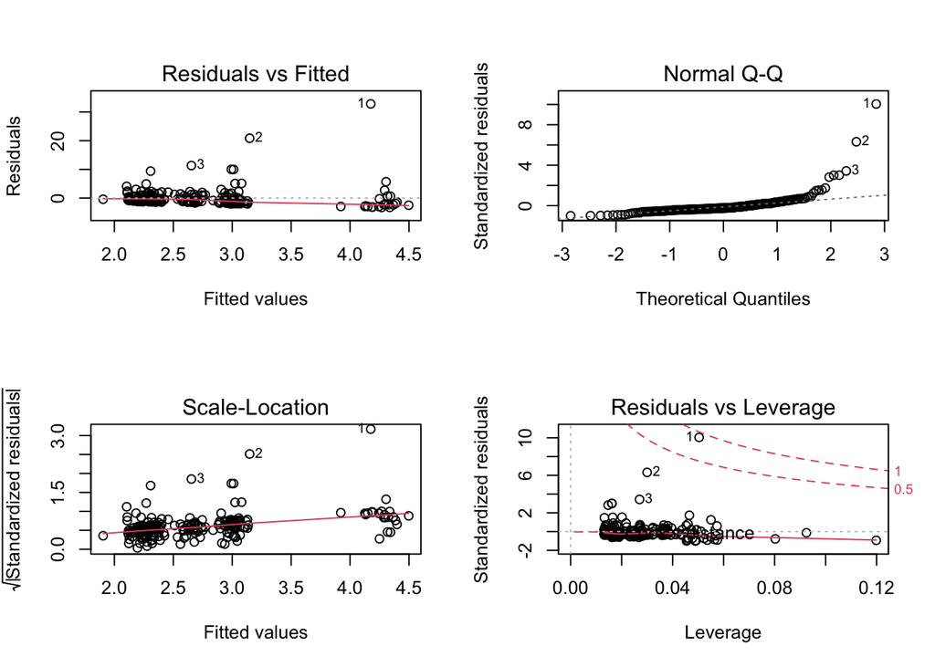

```r
# Ho : Errors are normally distributed; no heteroskedasticicty
# Ha : Errors are not normally distributed
# Decision Rule: p-value > 0.05 ==> Accept Ho

# Residual plots
newer.par = par(mfrow = c(2,2))
plot(reg1c)
```

```r
newer.par
```

```
## $mfrow
## [1] 1 1
```

From the residuals vs fitted values plot we see that the errors are present in groups - possibly on account of regions and hence not random. Outliers are also present

The QQ plot line is not at 45 degrees and points to non-normal distribution.

As seen the results of statistical tests are contradicting the actual plots. We further attempt transformation as indicated by the BoxCox test.

```r
# Fit transformation using reciprocal as per BoxCox test
reg1e <- lm((1/wealth)~., data = fortune)
summary(reg1e)
```

```
##
## Call:
## lm(formula = (1/wealth) ~ ., data = fortune)
##
## Residuals:
##      Min       1Q   Median       3Q      Max
## -0.53881 -0.22113  0.00826  0.20002  0.49803
##
## Coefficients:
##              Estimate Std. Error t value Pr(>|t|)
## (Intercept)  0.574005   0.091702   6.259 2.01e-09 ***
## age         -0.001044   0.001277  -0.818    0.414
## regionE      0.075583   0.051825   1.458    0.146
## regionM      0.044024   0.069603   0.633    0.528
## regionO      0.051481   0.064757   0.795    0.427
## regionU      0.042186   0.053708   0.785    0.433
## ---
## Signif. codes:  0 '***' 0.001 '**' 0.01 '*' 0.05 '.' 0.1 ' ' 1
##
## Residual standard error: 0.2585 on 219 degrees of freedom
## Multiple R-squared:  0.01276,    Adjusted R-squared:  -0.009775
## F-statistic: 0.5663 on 5 and 219 DF,  p-value: 0.7258
```

```r
# Check for assumptions of simple regression model

# SW Test for normality
# Ho : Errors are normally distributed
# Ha : Errors are not normally distributed
shapiro.test(reg1e$residuals)
```

```
##
##  Shapiro-Wilk normality test
##
## data:  reg1e$residuals
## W = 0.97385, p-value = 0.000351
```

```r
# BP Test for constancy of error variance
bptest(reg1e)
```

```
##
##  studentized Breusch-Pagan test
##
## data:  reg1e
## BP = 5.9572, df = 5, p-value = 0.3104
```

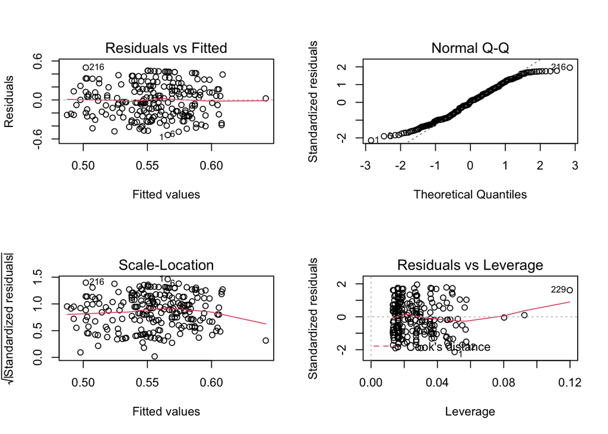

```r
# Ho : Errors are normally distributed; no heteroskedasticicty
# Ha : Errors are not normally distributed
# Decision Rule: p-value > 0.05 ==> Accept Ho

# Residual plots
newer.par = par(mfrow = c(2,2))
plot(reg1e)
```

```r
newer.par
```

```
## $mfrow
## [1] 1 1
```

From the residuals vs fitted values plot we see that the errors are now randomly distributed. Outliers are also reduced.

## Problem 2

Refer to the CDI data set. A regression model relating serious crime rate (Y, total serious crimes divided by total population) to population density ($X_1$, total population divided by land area) and unemployment rate ($X_3$) is to be constructed. (30 points, 10 points each)

a-) Fit second-order regression model. Plot the residuals against the fitted values. How well does the second-order model appear to fit the data? What is $R^2$?

```r
cdi <- read.csv('CDI Data.csv')
head(cdi)
```

```
##   Identification.number      County State Land.area Total.population
## 1                     1 Los_Angeles    CA      4060          8863164
## 2                     2        Cook    IL       946          5105067
## 3                     3      Harris    TX      1729          2818199
## 4                     4   San_Diego    CA      4205          2498016
## 5                     5      Orange    CA       790          2410556
## 6                     6       Kings    NY        71          2300664
##   Percent.of.population.aged.18.34 Percent.of.population.65.or.older
## 1                             32.1                               9.7
## 2                             29.2                              12.4
## 3                             31.3                               7.1
## 4                             33.5                              10.9
## 5                             32.6                               9.2
## 6                             28.3                              12.4
##   Number.of.active.physicians Number.of.hospital.beds Total.serious.crimes
```

[output cut: 27 more lines]

```r
summary(cdi)
```

```
##  Identification.number    County             State             Land.area
##  Min.   :  1.0         Length:440         Length:440         Min.   :   15.0
##  1st Qu.:110.8         Class :character   Class :character   1st Qu.:  451.2
##  Median :220.5         Mode  :character   Mode  :character   Median :  656.5
##  Mean   :220.5                                               Mean   : 1041.4
##  3rd Qu.:330.2                                               3rd Qu.:  946.8
##  Max.   :440.0                                               Max.   :20062.0
##  Total.population  Percent.of.population.aged.18.34
##  Min.   : 100043   Min.   :16.40
##  1st Qu.: 139027   1st Qu.:26.20
##  Median : 217280   Median :28.10
##  Mean   : 393011   Mean   :28.57
##  3rd Qu.: 436064   3rd Qu.:30.02
##  Max.   :8863164   Max.   :49.70
##  Percent.of.population.65.or.older Number.of.active.physicians
##  Min.   : 3.000                    Min.   :   39.0
##  1st Qu.: 9.875                    1st Qu.:  182.8
##  Median :11.750                    Median :  401.0
##  Mean   :12.170                    Mean   :  988.0
##  3rd Qu.:13.625                    3rd Qu.: 1036.0
##  Max.   :33.800                    Max.   :23677.0
##  Number.of.hospital.beds Total.serious.crimes Percent.high.school.graduates
##  Min.   :   92.0         Min.   :   563       Min.   :46.60
##  1st Qu.:  390.8         1st Qu.:  6220       1st Qu.:73.88
##  Median :  755.0         Median : 11820       Median :77.70
##  Mean   : 1458.6         Mean   : 27112       Mean   :77.56
##  3rd Qu.: 1575.8         3rd Qu.: 26280       3rd Qu.:82.40
##  Max.   :27700.0         Max.   :688936       Max.   :92.90
##  Percent.bachelor.s.degrees Percent.below.poverty.level Percent.unemployment
##  Min.   : 8.10              Min.   : 1.400              Min.   : 2.200
##  1st Qu.:15.28              1st Qu.: 5.300              1st Qu.: 5.100
##  Median :19.70              Median : 7.900              Median : 6.200
##  Mean   :21.08              Mean   : 8.721              Mean   : 6.597
##  3rd Qu.:25.32              3rd Qu.:10.900              3rd Qu.: 7.500
##  Max.   :52.30              Max.   :36.300              Max.   :21.300
##  Per.capita.income Total.personal.income Geographic.region
##  Min.   : 8899     Min.   :  1141        Min.   :1.000
##  1st Qu.:16118     1st Qu.:  2311        1st Qu.:2.000
##  Median :17759     Median :  3857        Median :3.000
##  Mean   :18561     Mean   :  7869        Mean   :2.461
##  3rd Qu.:20270     3rd Qu.:  8654        3rd Qu.:3.000
##  Max.   :37541     Max.   :184230        Max.   :4.000
```

```r
str(cdi)
```

```
## 'data.frame':    440 obs. of  17 variables:
##  $ Identification.number            : int  1 2 3 4 5 6 7 8 9 10 ...
##  $ County                           : chr  "Los_Angeles" "Cook" "Harris" "San_Diego" ...
##  $ State                            : chr  "CA" "IL" "TX" "CA" ...
##  $ Land.area                        : int  4060 946 1729 4205 790 71 9204 614 1945 880 ...
##  $ Total.population                 : int  8863164 5105067 2818199 2498016 2410556 2300664 2122101 2111687 1937094 1852810 ...
##  $ Percent.of.population.aged.18.34 : num  32.1 29.2 31.3 33.5 32.6 28.3 29.2 27.4 27.1 32.6 ...
##  $ Percent.of.population.65.or.older: num  9.7 12.4 7.1 10.9 9.2 12.4 12.5 12.5 13.9 8.2 ...
##  $ Number.of.active.physicians      : int  23677 15153 7553 5905 6062 4861 4320 3823 6274 4718 ...
##  $ Number.of.hospital.beds          : int  27700 21550 12449 6179 6369 8942 6104 9490 8840 6934 ...
##  $ Total.serious.crimes             : int  688936 436936 253526 173821 144524 680966 177593 193978 244725 214258 ...
##  $ Percent.high.school.graduates    : num  70 73.4 74.9 81.9 81.2 63.7 81.5 70 65 77.1 ...
##  $ Percent.bachelor.s.degrees       : num  22.3 22.8 25.4 25.3 27.8 16.6 22.1 13.7 18.8 26.3 ...
##  $ Percent.below.poverty.level      : num  11.6 11.1 12.5 8.1 5.2 19.5 8.8 16.9 14.2 10.4 ...
##  $ Percent.unemployment             : num  8 7.2 5.7 6.1 4.8 9.5 4.9 10 8.7 6.1 ...
##  $ Per.capita.income                : int  20786 21729 19517 19588 24400 16803 18042 17461 17823 21001 ...
##  $ Total.personal.income            : int  184230 110928 55003 48931 58818 38658 38287 36872 34525 38911 ...
##  $ Geographic.region                : int  4 2 3 4 4 1 4 2 3 3 ...
```

```r
crime_rate <- cdi$Total.serious.crimes/cdi$Total.population
pop_den <- cdi$Total.population/cdi$Land.area
unemp <- cdi$Percent.unemployment

y <- crime_rate
x1 <- pop_den
x3 <- unemp

# fit the 2nd order model
y <- crime_rate
x1 <- scale(pop_den, scale = FALSE)
x3 <- scale(unemp, scale = FALSE)
x11 <- x1^2
x32 <- x3^2
x13 <- x1*x3

reg2a <- lm(y~x1+I(x1^2)+x3+I(x3^2)+(x1*x3))
summary(reg2a)
```

```
##
## Call:
## lm(formula = y ~ x1 + I(x1^2) + x3 + I(x3^2) + (x1 * x3))
##
## Residuals:
##       Min        1Q    Median        3Q       Max
## -0.055642 -0.016851 -0.002889  0.014810  0.085485
##
## Coefficients:
##               Estimate Std. Error t value Pr(>|t|)
## (Intercept)  5.629e-02  1.260e-03  44.662  < 2e-16 ***
## x1           4.585e-06  9.841e-07   4.659 4.23e-06 ***
## I(x1^2)      2.698e-12  5.932e-11   0.045   0.9637
## x3          -8.800e-05  6.276e-04  -0.140   0.8886
## I(x3^2)      1.629e-04  9.541e-05   1.708   0.0884 .
## x1:x3        8.334e-07  4.091e-07   2.037   0.0423 *
## ---
## Signif. codes:  0 '***' 0.001 '**' 0.01 '*' 0.05 '.' 0.1 ' ' 1
##
## Residual standard error: 0.02383 on 434 degrees of freedom
## Multiple R-squared:  0.2485, Adjusted R-squared:  0.2398
## F-statistic:  28.7 on 5 and 434 DF,  p-value: < 2.2e-16
```

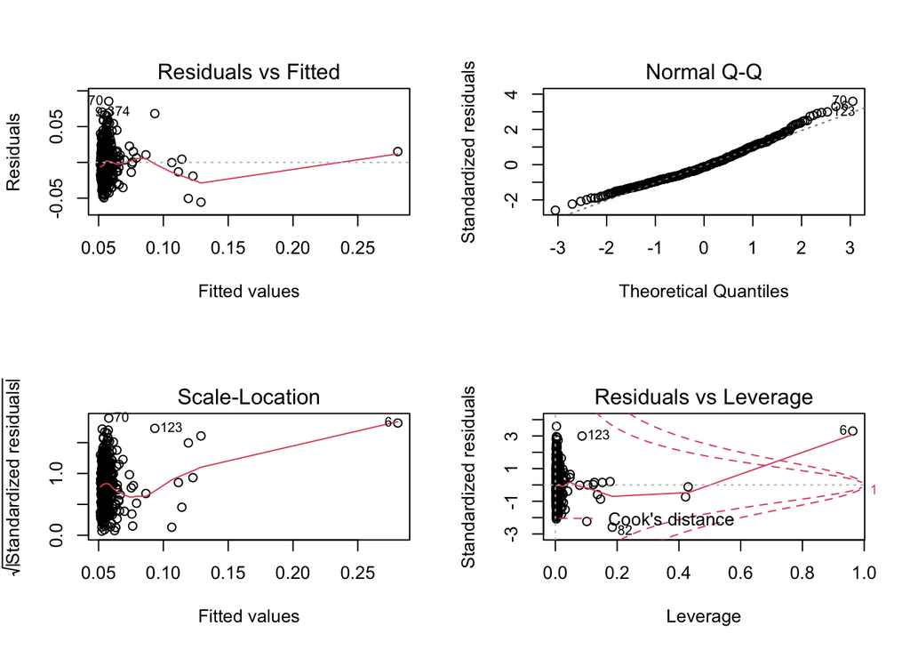

```r
newer.par = par(mfrow = c(2,2))
plot(reg2a)
```

```r
newer.par
```

```
## $mfrow
## [1] 1 1
```

The R2 of the model is 0.2485 and adjusted R2 of the model is 0.2398.

From the residual vs fitted values plot we see that the residuals are not independent and we have outliers in the data while the QQ plot appears to be in order.

b-) Test whether or not all quadratic and interaction terms can be dropped from the regression model; use $\alpha$ = .01. State the alternatives, decision rule, and conclusion.

```r
# fit 1st order model - reduced model
reg2b <- lm(y~x1+x3)
summary(reg2b)
```

```
##
## Call:
## lm(formula = y ~ x1 + x3)
##
## Residuals:
##       Min        1Q    Median        3Q       Max
## -0.053806 -0.016940 -0.003898  0.014680  0.084508
##
## Coefficients:
##              Estimate Std. Error t value Pr(>|t|)
## (Intercept) 5.729e-02  1.144e-03  50.054   <2e-16 ***
## x1          5.973e-06  5.222e-07  11.439   <2e-16 ***
## x3          3.618e-04  4.902e-04   0.738    0.461
## ---
## Signif. codes:  0 '***' 0.001 '**' 0.01 '*' 0.05 '.' 0.1 ' ' 1
##
## Residual standard error: 0.02401 on 437 degrees of freedom
## Multiple R-squared:  0.2318, Adjusted R-squared:  0.2283
## F-statistic: 65.92 on 2 and 437 DF,  p-value: < 2.2e-16
```

```r
# anova of reduced model and full model
anova(reg2b, reg2a)
```

```
## Analysis of Variance Table
##
## Model 1: y ~ x1 + x3
## Model 2: y ~ x1 + I(x1^2) + x3 + I(x3^2) + (x1 * x3)
##   Res.Df     RSS Df Sum of Sq      F  Pr(>F)
## 1    437 0.25186
## 2    434 0.24638  3  0.005477 3.2159 0.02278 *
## ---
## Signif. codes:  0 '***' 0.001 '**' 0.01 '*' 0.05 '.' 0.1 ' ' 1
```

Comparing the R2 values of full and reduced models we see that the values are nearly similar.

Ho : Quadratic and interaction terms can be dropped Ha : Quadratic and interaction terms are needed.

The anova test of the full and reduced models also shows that the incremental addition of sum of squares is very small.

The p-value = 0.02278 is greater than the alpha = 0.01 and we accept Ho; conclude that the variables can be dropped.

c-) Instead of the predictor variable population density, total population ($X_1$ and land area ($X_2$) are to be employed as separate predictor variables, in addition to unemployment rate ($X_3$). The regression model should contain linear and quadratic terms for total population, and linear terms only for land area and unemployment rate. (No interaction terms are to be included in this model.) Fit this regression model and obtain $R^2$. Is this coefficient of multiple determination substantially different from the one for the regression model in part (a)?

```r
crime_rate <- cdi$Total.serious.crimes/cdi$Total.population
population <- cdi$Total.population
land_area <- cdi$Land.area
unemp <- cdi$Percent.unemployment

y <- crime_rate
x1 <- scale(population, scale = FALSE)
x2 <- scale(land_area, scale = FALSE)
x3 <- scale(unemp, scale = FALSE)

x12 <- x1

reg2c <- lm(y~x1 + I(x1^2)+x2+x3)
summary(reg2c)
```

```
##
## Call:
## lm(formula = y ~ x1 + I(x1^2) + x2 + x3)
##
## Residuals:
##      Min       1Q   Median       3Q      Max
## -0.05967 -0.01704 -0.00303  0.01410  0.19106
##
## Coefficients:
##               Estimate Std. Error t value Pr(>|t|)
## (Intercept)  5.850e-02  1.229e-03  47.595  < 2e-16 ***
## x1           2.942e-08  3.555e-09   8.276 1.57e-15 ***
## I(x1^2)     -3.356e-15  5.878e-16  -5.710 2.10e-08 ***
## x2          -5.576e-07  8.123e-07  -0.687    0.493
## x3           6.824e-04  5.302e-04   1.287    0.199
## ---
## Signif. codes:  0 '***' 0.001 '**' 0.01 '*' 0.05 '.' 0.1 ' ' 1
##
## Residual standard error: 0.02539 on 435 degrees of freedom
## Multiple R-squared:  0.1444, Adjusted R-squared:  0.1365
## F-statistic: 18.35 on 4 and 435 DF,  p-value: 6.022e-14
```

```r
# comparing with part a
# we assume that 2c is the reduced model since it has quadratic term for x1 and linear terms for others.
anova(reg2c, reg2a)
```

```
## Analysis of Variance Table
##
## Model 1: y ~ x1 + I(x1^2) + x2 + x3
## Model 2: y ~ x1 + I(x1^2) + x3 + I(x3^2) + (x1 * x3)
##   Res.Df     RSS Df Sum of Sq      F   Pr(>F)
## 1    435 0.28051
## 2    434 0.24638  1  0.034121 60.103 6.46e-14 ***
## ---
## Signif. codes:  0 '***' 0.001 '**' 0.01 '*' 0.05 '.' 0.1 ' ' 1
```

The R2 of the model in part ‘c’ is 0.1444 with adjusted R2 of 0.1365.

The R2 of the model in part ‘a’ is 0.2485 with adjusted R2 of 0.2398.

Ho : Interaction terms are not needed; 2a and 2c are similar Ha : Interaction terms are needed; 2a and 2c are substantially different

The anova test gives us a p-value of 6.46e-14 which means that the result is significant at alpha = 0.001

Hence, we reject Ho conclude that the result in part ‘c’ is substantially different from that in part ‘a’.

## Problem 3

Refer to the CDI data set. The number of active physicians (Y) is to be regressed against total population ($X_1$), total personal income ($X_2$), and geographic region ($X_3$, $X_4$ , $X_5$). (20 points, 10 points each)

(“(”Geographic region classification is that used by the U.S. Bureau of the Census, where: 1 = NE, 2 = NC, S = 3, W=4")

a-) Fit a first-order regression model. Let $X_3$ = 1 if NE and 0 otherwise, $X_4$ = 1 if NC and 0 otherwise, and $X_5$ = 1 if S and 0 otherwise. Examine whether the effect for the northeastern region on number of active physicians differs from the effect for the north central region by constructing an appropriate 90 percent confidence interval. Interpret your interval estimate.

```r
y <- cdi$Number.of.active.physicians
x1 <- cdi$Total.population
x2 <- cdi$Total.personal.income
x3 <- as.numeric(cdi$Geographic.region==1) # NE
x4 <- as.numeric(cdi$Geographic.region==2) # NC
x5 <- as.numeric(cdi$Geographic.region==3) # S

reg3a <- lm(y~x1+x2+x3+x4+x5)
summary(reg3a)
```

```
##
## Call:
## lm(formula = y ~ x1 + x2 + x3 + x4 + x5)
##
## Residuals:
##     Min      1Q  Median      3Q     Max
## -1866.8  -207.7   -81.5    72.4  3721.7
##
## Coefficients:
##               Estimate Std. Error t value Pr(>|t|)
## (Intercept) -2.075e+02  7.028e+01  -2.952  0.00332 **
## x1           5.515e-04  2.835e-04   1.945  0.05243 .
## x2           1.070e-01  1.325e-02   8.073  6.8e-15 ***
## x3           1.490e+02  8.683e+01   1.716  0.08685 .
## x4           1.455e+02  8.515e+01   1.709  0.08817 .
## x5           1.912e+02  8.003e+01   2.389  0.01731 *
## ---
## Signif. codes:  0 '***' 0.001 '**' 0.01 '*' 0.05 '.' 0.1 ' ' 1
##
## Residual standard error: 566.1 on 434 degrees of freedom
## Multiple R-squared:  0.9011, Adjusted R-squared:  0.8999
## F-statistic: 790.7 on 5 and 434 DF,  p-value: < 2.2e-16
```

```r
# confidence interval
confint(reg3a, level = 1-0.1/2)
```

```
##                     2.5 %        97.5 %
## (Intercept) -3.456304e+02 -69.361106971
## x1          -5.828310e-06   0.001108748
## x2           8.095958e-02   0.133063482
## x3          -2.164623e+01 319.685375829
## x4          -2.183695e+01 312.889843723
## x5           3.391581e+01 348.516796471
```

The model has a very high R2 of 0.9011 and adjusted R2 of 0.8999

Hence, we conclude that both have similar effects.

b-) Test whether any geographic effects are present; use $\alpha$ = .10. State the alternatives, decision rule, and conclusion. What is the P-value of the test?

```r
# reduced model without geographic effects
reg3b <- lm(y~x1+x2)
summary(reg3b)
```

```
##
## Call:
## lm(formula = y ~ x1 + x2)
##
## Residuals:
##     Min      1Q  Median      3Q     Max
## -1849.1  -198.3   -71.4    39.7  3755.3
##
## Coefficients:
##               Estimate Std. Error t value Pr(>|t|)
## (Intercept) -6.444e+01  3.283e+01  -1.963   0.0503 .
## x1           5.310e-04  2.775e-04   1.914   0.0563 .
## x2           1.072e-01  1.297e-02   8.269 1.64e-15 ***
## ---
## Signif. codes:  0 '***' 0.001 '**' 0.01 '*' 0.05 '.' 0.1 ' ' 1
##
## Residual standard error: 568 on 437 degrees of freedom
## Multiple R-squared:  0.8998, Adjusted R-squared:  0.8993
## F-statistic:  1961 on 2 and 437 DF,  p-value: < 2.2e-16
```

```r
# anova of full and reduced model.
anova(reg3b, reg3a)
```

```
## Analysis of Variance Table
##
## Model 1: y ~ x1 + x2
## Model 2: y ~ x1 + x2 + x3 + x4 + x5
##   Res.Df       RSS Df Sum of Sq      F Pr(>F)
## 1    437 140967081
## 2    434 139093455  3   1873626 1.9487  0.121
```

Ho : geographic variables not needed Ha : geographic variables are needed